# EU-27 Green-Transition Typology: Design & Results

Vulnerability × Potential map — self-contained reproduction for review

# 1 Research question & motivation

- **Project (WP1, OPUS “Green transition & economic polarization in Europe”).** Build a national taxonomy of the EU-27 that captures how well-placed each Member State is for the green transition, and ask whether the transition risks **reinforcing existing core–periphery polarization**.
- **Design (proposal Fig. 1).** Two *vulnerabilities* (transition burden) and two *potentials* (green capability), placed on a 2-D **vulnerability × potential map** with four quadrants (Winners / Exposed / Low-stakes / At risk).
- **Guiding requirements for the axes:**
  - Each axis must be **distinct** from the other and **not merely a proxy for GDP per capita** — but income relevance is *expected and welcome*, not something to engineer away.
  - The axes must **differentiate** countries (a visible growth-model story), else there is nothing to build a narrative on.
  - No **double-counting**: two near-identical indicators should not silently dominate a block.

# 2 Method

## 2.1 Indicators (six, two per dimension)

- **Vulnerability**
  - *Emission intensity of production* — **carbon intensity** (GHG / value added) and **energy intensity** (final energy / value added).
  - *Fossil dependency* — **fossil share of gross available energy** (demand side).
- **Potential**
  - *Green economic complexity* — **GCI** (current green export complexity) and **GCP** (connectedness / potential to diversify into green products).
  - *Green innovation* — **green patents** per capita.

## 2.2 Fossil share: demand-side, not production-side

- The fossil share is measured on **gross available energy** (what a country *consumes*), replacing the earlier *fossil share of primary production* (what it *extracts*). The two barely agree (r = 0.34).

Production- vs demand-based fossil share (selected).

| country | fossil (production) | fossil (gross avail.) |
| --- | --- | --- |
| Germany | 0.43 | 0.82 |
| Denmark | 0.73 | 0.69 |
| Estonia | 0.00 | 0.86 |
| Ireland | 0.37 | 0.91 |
| Luxembourg | 0.00 | 0.83 |
| Malta | 0.00 | 0.96 |

- The production measure is **0 for every non-producer** (Malta, Luxembourg, Baltics) and even mis-codes oil-shale Estonia — an artifact. The demand measure captures actual fossil **dependence** and has full EU-27 coverage.

## 2.3 Scoring: two-part axes (twin sub-index + standalone)

- Within each block the two intensity / two complexity indicators are **strongly correlated** — they are two facets of *one* construct, not independent variables.

Within-block correlations: the twins cohere; the standalone is distinct.

| pair | correlation |
| --- | --- |
| carbon intensity ↔︎ energy intensity | 0.68 |
| GCI ↔︎ GCP | 0.78 |
| intensity twins ↔︎ fossil | 0.07 |
| complexity twins ↔︎ patents | 0.18 |

- So each axis is built in two steps: **(1)** reduce the correlated twin pair to a single sub-index (first principal component); **(2)** combine that sub-index with the standalone indicator at **equal weight** (standardised mean). This treats the two parts as **co-equal conceptual dimensions**, so neither the twin pair (2 indicators) nor the standalone (1 indicator) dominates by count.
- Contrast with a **flat PCA** over all three variables per block: there the correlated twins dominate PC1 and the standalone loads only ~0.14–0.28, i.e. is almost ignored.

# 3 Results

## 3.1 Axes are distinct, differentiating, and income-balanced

Go/no-go and differentiation diagnostics (structured axes).

| metric | value |
| --- | --- |
| cor(vulnerability, potential) | -0.57 |
| R² vulnerability ~ log GDP p.c. | 0.25 |
| R² potential ~ log GDP p.c. | 0.33 |
| eta² vulnerability ~ growth model | 0.37 |
| eta² potential ~ growth model | 0.44 |

- **Distinct axes:** cor(vulnerability, potential) = −0.57 — related (high burden tends to pair with low capability) but far from ±1, so not one axis in disguise.
- **Income present but balanced:** both R²(~log GDP) are moderate (0.25 / 0.33). Income matters in *both* blocks, dominates *neither*. This is by design: within each block one part is income-linked and one income-neutral, on opposite diagonals (intensity & patents track GDP; fossil & complexity do not).
- **Differentiation:** eta² (variance explained by growth model) is high on both axes — the core–periphery structure is clearly visible.

## 3.2 The typology map

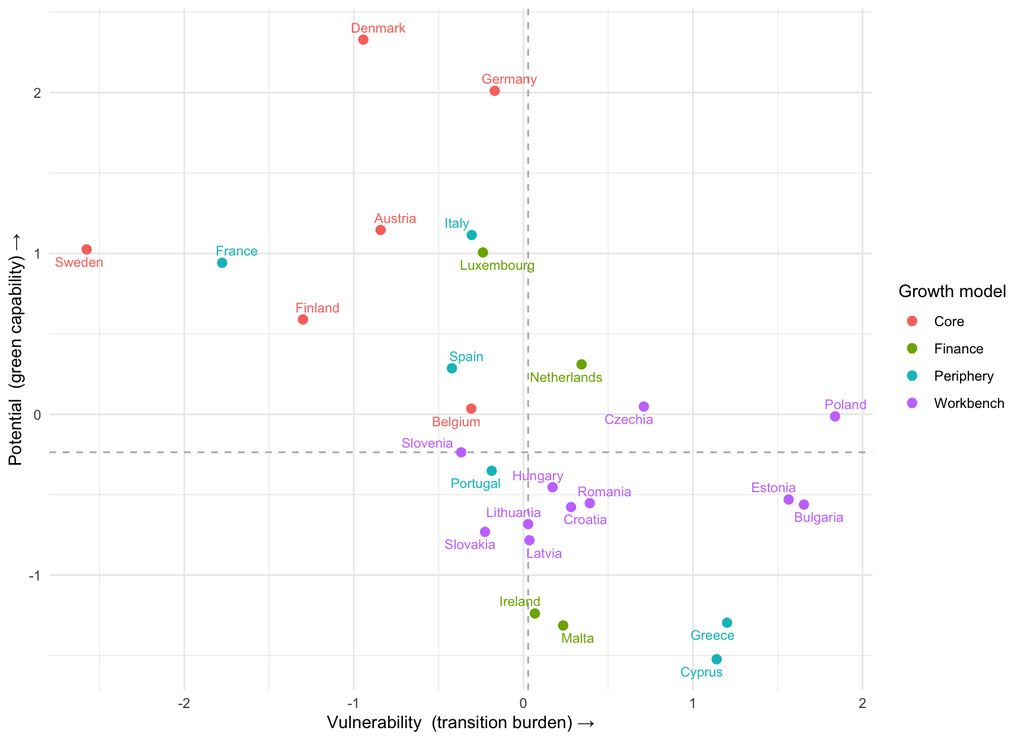

Quadrant membership (structured axes).

| Quadrant | Countries |
| --- | --- |
| At risk | Bulgaria, Croatia, Cyprus, Estonia, Greece, Hungary, Ireland, Latvia, Lithuania, Malta, Romania |
| Exposed | Czechia, Netherlands, Poland |
| Low-stakes | Portugal, Slovakia |
| Winners | Austria, Belgium, Denmark, Finland, France, Germany, Italy, Luxembourg, Slovenia, Spain, Sweden |

# 4 Validation

## 4.1 External validity: do the axes predict what they should?

The scores are validated against outcomes **not used to build them**, controlling for income (partial correlation net of log GDP p.c.): the overall **renewable share** (Eurostat SHARES REN), **real GDP growth** over the window, and the OECD **Environmental Policy Stringency** index (EPS, 20/27 countries).

Correlation of each axis with external validators (partial = net of log GDP p.c.).

| score | outcome | raw_cor | partial_cor |
| --- | --- | --- | --- |
| vulnerability | renew_share | -0.46 | -0.51 |
| vulnerability | gdp_growth | 0.27 | 0.17 |
| vulnerability | eps | -0.39 | -0.39 |
| potential | renew_share | 0.25 | 0.36 |
| potential | gdp_growth | -0.55 | -0.42 |
| potential | eps | 0.58 | 0.63 |

## 4.2 Relation to the development-model classification

The central polarization question is how the green-transition typology relates to the **Gräbner et al. (2020)** European growth-model classification: **Core** (DE, AT, BE, DK, FI, SE), **Finance** (LU, NL, MT, IE), **Periphery** (FR, GR, IT, PT, ES, CY), **Workbench** (the eastern catch-up economies).

Mean axis scores by growth-model group.

| Growth model | n | vulnerability | potential |
| --- | --- | --- | --- |
| Core | 6 | -1.02 | 1.19 |
| Periphery | 6 | -0.06 | -0.14 |
| Finance | 4 | 0.10 | -0.31 |
| Workbench | 11 | 0.55 | -0.46 |

Quadrant × growth model (Cramér’s V = 0.45; descriptive, n = 27).

|  | Core | Finance | Periphery | Workbench |
| --- | --- | --- | --- | --- |
| At risk | 0 | 2 | 2 | 7 |
| Exposed | 0 | 1 | 0 | 2 |
| Low-stakes | 0 | 0 | 1 | 1 |
| Winners | 6 | 1 | 3 | 1 |

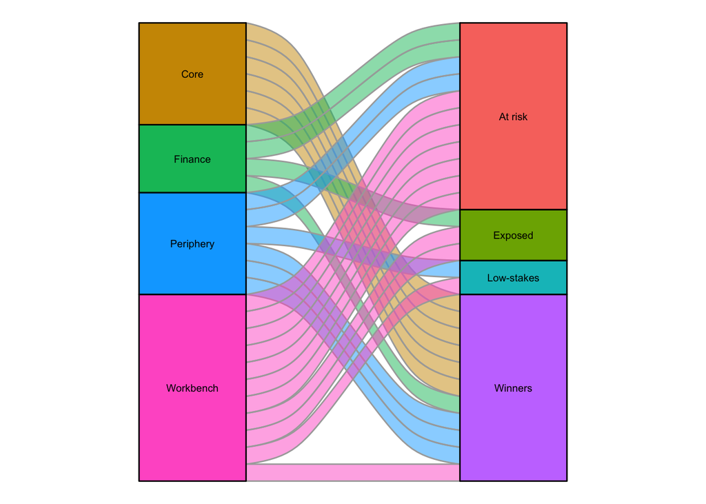

- **The typology tracks the development model, but does not reproduce it** (Cramér’s V moderate, not 1): growth model and transition quadrant are clearly associated, yet the mapping is many-to-many.
- **Core → mostly Winners; Workbench → mostly At risk** — the transition risks **reinforcing** the existing core–periphery divide (the polarization hypothesis).
- **But the typology adds resolution the development model lacks:**
  - *Finance* splits — clean, high-innovation **Luxembourg → Winners** vs. fossil-dependent, low-complexity **Malta / Ireland → At risk**.
  - *Periphery* splits — larger economies (IT, ES) sit near *Winners* while **Portugal** drops toward *Low-stakes*.
  - Within *Workbench*, coal-heavy **Poland / Czechia** are *Exposed* (real burden) while cleaner **Slovakia** is *Low-stakes* — a distinction the single development-model label hides.

# 5 Robustness

## 5.1 Stability to the aggregation choice

The headline combines each block as a twin sub-index + standalone. As an alternative, each block can be reduced by a **single PCA over all three variables** (which lets the correlated twins dominate). The map is **stable** to this choice:

Countries differing between single-PCA blocks and the structured axes (8 of 27).

| country | group | single PCA | structured |
| --- | --- | --- | --- |
| Finland | Core | Exposed | Winners |
| Ireland | Finance | Low-stakes | At risk |
| Luxembourg | Finance | Low-stakes | Winners |
| Malta | Finance | Low-stakes | At risk |
| Netherlands | Finance | Winners | Exposed |
| Portugal | Periphery | Winners | Low-stakes |
| Slovakia | Workbench | At risk | Low-stakes |
| Slovenia | Workbench | Exposed | Winners |

- Only **8 of 27** countries differ, so the classification is not an artifact of the aggregation rule.
- The differences are interpretable: the structured axes give the **standalone** dimensions real weight, so high-innovation economies (Luxembourg, Slovenia, Finland) and fossil-dependent ones (Malta, Ireland) are placed on their own merits rather than being absorbed by the correlated twins.
- Further checks in `07_robustness.R`, all against the structured headline, are reassuring: the twin sub-index as a mean instead of PC1 (0/27), robust scaling (2/27), ECI for GCI (0/27), renewable-only GCI (2/27), indicator-window shifts (0/27) and single-country drops (1/26). The map moves most under the two genuine measurement choices — flat aggregation (8/27) and the production-based fossil share (8/27) — which is why both are argued for explicitly in the Method.

# 6 Interpretation